# BIOL606_hw_Lecture06_Hastings

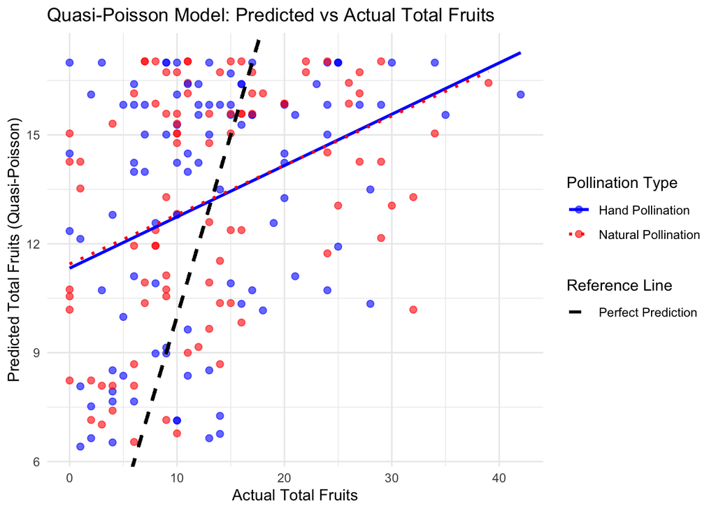

```r
# Define min/max values for totalfruits to keep the line within the data range
min_fruit <- min(cucumber_damage$totalfruits, na.rm = TRUE)
max_fruit <- max(cucumber_damage$totalfruits, na.rm = TRUE)

# Plot results for the Quasi-Poisson model
results_2 <- ggplot(cucumber_damage, aes(x = totalfruits, y = predicted_qp, color = pollination)) +
  geom_point(alpha = 0.6, size = 2) +  # Scatter plot of actual vs. predicted values.

  # Add restricted reference line using geom_segment()
  geom_segment(aes(linetype = 'Perfect Prediction'), x = min_fruit, y = min_fruit, xend = max_fruit, yend = max_fruit,
               color = 'black', size = 1) +

  # Separate smooth lines for each pollination treatment
  geom_smooth(data = subset(cucumber_damage, pollination == 'HP'), method = 'lm', se = FALSE, linetype = 'solid', size = 1) +
  geom_smooth(data = subset(cucumber_damage, pollination == 'NP'), method = 'lm', se = FALSE, linetype = 'dotted', size = 1) +

  scale_color_manual(
    name = 'Pollination Type',
    values = c('HP' = 'blue', 'NP' = 'red'),
    labels = c('HP' = 'Hand Pollination', 'NP' = 'Natural Pollination')
  ) +

  scale_linetype_manual(
    name = 'Reference Line',
    values = c('Perfect Prediction' = 'dashed')
  ) +

  labs(
    title = 'Quasi-Poisson Model: Predicted vs Actual Total Fruits',
    x = 'Actual Total Fruits',
    y = 'Predicted Total Fruits (Quasi-Poisson)'
  ) +

  theme_minimal()

results_2  # Display the plot
```

**Question 3:** Repeat steps 1 & 2 but use the categorical treatment ‘herbivory’.

```r
# Load dataset.
cucumber_damage <- read.csv('lecture6_NEWcucumberdamage.csv') # Load in lecture6_NEWcucumberdamage.csv data set.
glimpse(cucumber_damage)
```

```
## Rows: 200
## Columns: 7
## $ plant       <int> 41, 42, 43, 44, 45, 46, 47, 48, 49, 50, 51, 52, 53, 54, 55…
## $ block       <int> 6, 6, 6, 6, 6, 6, 6, 6, 7, 7, 7, 7, 7, 7, 7, 7, 8, 8, 8, 8…
## $ herbivory   <chr> "H", "M", "L", "L", "O", "H", "M", "O", "L", "H", "M", "M"…
## $ pollination <chr> "NP", "HP", "HP", "NP", "HP", "HP", "NP", "NP", "NP", "HP"…
## $ num_leaves  <int> 5, 9, 11, 3, 14, 2, 3, 10, 5, 1, 13, 13, 12, 8, 10, 4, 9, …
## $ leafdamage  <int> 50, 13, 4, 7, 4, 40, 18, 1, 4, 39, 18, 19, 3, 4, 7, 32, 0,…
## $ totalfruits <int> 3, 28, 29, 15, 6, 5, 8, 22, 20, 4, 0, 29, 6, 14, 24, 13, 9…
```

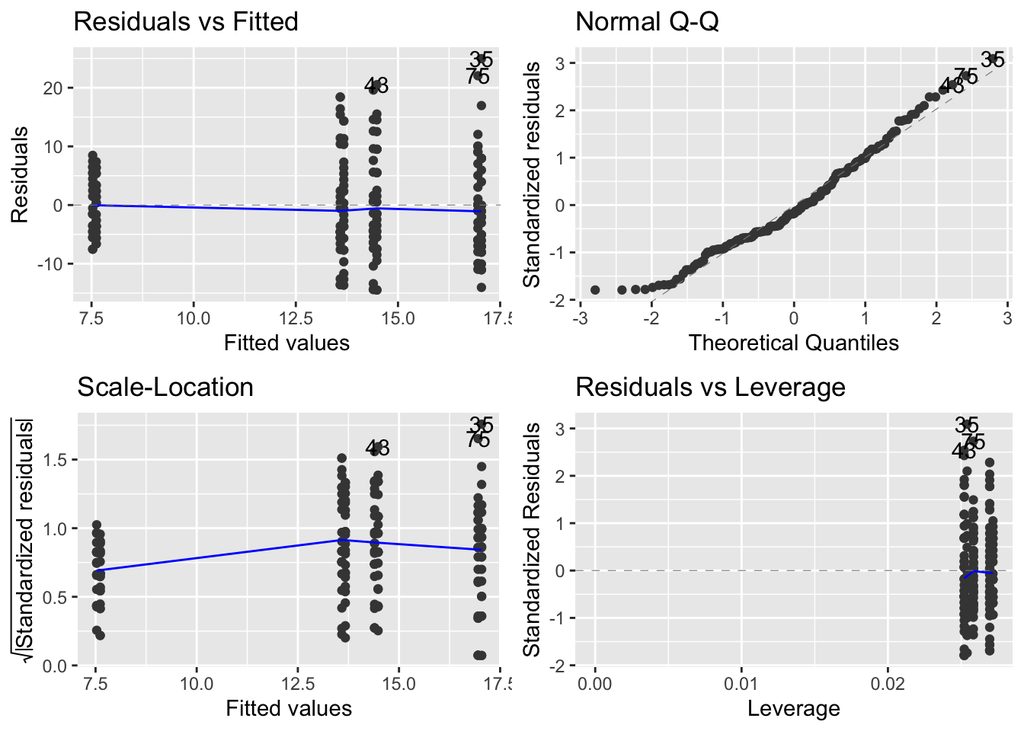

```r
# ===== General Linear Model =====

# Create general linear model.
model_3 <- lm(totalfruits ~ herbivory + pollination, data = cucumber_damage)

# Generate diagnostic plots to check model_3 assumptions.
autoplot(model_3)
```

```r
# Perform ANOVA test on model_3 significance of predictors.
anova(model_3)
```

```
## Analysis of Variance Table
##
## Response: totalfruits
##              Df  Sum Sq Mean Sq F value    Pr(>F)
## herbivory     3  2280.3  760.10 11.3600 7.039e-07 ***
## pollination   1     0.4    0.36  0.0053    0.9418
## Residuals   187 12512.2   66.91
## ---
## Signif. codes:  0 '***' 0.001 '**' 0.01 '*' 0.05 '.' 0.1 ' ' 1
```

```r
# Display summary of model_3.
summary(model_3)
```

```
##
## Call:
## lm(formula = totalfruits ~ herbivory + pollination, data = cucumber_damage)
##
## Residuals:
##     Min      1Q  Median      3Q     Max
## -14.483  -5.587  -1.440   5.483  24.958
##
## Coefficients:
##               Estimate Std. Error t value Pr(>|t|)
## (Intercept)    7.61487    1.31506   5.791 2.92e-08 ***
## herbivoryL     6.86829    1.66230   4.132 5.42e-05 ***
## herbivoryM     6.05872    1.69694   3.570 0.000453 ***
## herbivoryO     9.42741    1.67026   5.644 6.07e-08 ***
## pollinationNP -0.08631    1.18131  -0.073 0.941834
## ---
## Signif. codes:  0 '***' 0.001 '**' 0.01 '*' 0.05 '.' 0.1 ' ' 1
##
## Residual standard error: 8.18 on 187 degrees of freedom
##   (8 observations deleted due to missingness)
## Multiple R-squared:  0.1542, Adjusted R-squared:  0.1361
## F-statistic: 8.521 on 4 and 187 DF,  p-value: 2.448e-06
```

## General Linear Model (model_3) Diagonostics

**Autoplot Output**  
1) Residuals vs Fitted: Residuals are clustered around fitted values likely due to herbivory being a categorical variable. No clear curvature suggesting linearity.  
2) Normal Q-Q: Residuals are approximately normal, some points on the tails suggest potential outliers.  
3) Scale-Location: The trend line curves slightly, suggesting an increased variance in residuals as the fitted values increase.  
4) Residuals vs Leverage: Almost all points have a very low leverage with some outliers but the outliers still don’t have a very high leverage.  
**ANOVA Output**  
- Herbivory has a significant effect on total fruits (p-value = 7.039e-07).  
- Pollination type has no significant effect on total fruits.  
- The residual Sum Sq = 12512.2 indicating a large portion of variation remains unexplained.  
**Summary of model_3**  
- Median residual is close to 0 - model doesn’t have a strong bias.  
- Range of residuals is not very extreme.  
- Baseline condition: H (high herbivory) & HP (hand pollination). - Low herbivory (compared to H) produces 6.87 more fruits than H (significant, p < 0.001). - Medium herbivory (compared to H) produces 6.06 more fruits than H (significant, p < 0.001). - Other herbivory (compared to H) produces 9.43 more fruits than H (significant, p < 0.001). - Higher herbivory reduces fruit production. - Pollination does not have a significant effect.  
- The Multiple R-squared suggests only ~15.42% of the variance is explained by the model.  
- Overall p-value (2.45e-06) suggests the model is statistically significant.

```r
# Load dataset.
cucumber_damage <- read.csv('lecture6_NEWcucumberdamage.csv') # Load in lecture6_NEWcucumberdamage.csv data set.
glimpse(cucumber_damage)
```

```
## Rows: 200
## Columns: 7
## $ plant       <int> 41, 42, 43, 44, 45, 46, 47, 48, 49, 50, 51, 52, 53, 54, 55…
## $ block       <int> 6, 6, 6, 6, 6, 6, 6, 6, 7, 7, 7, 7, 7, 7, 7, 7, 8, 8, 8, 8…
## $ herbivory   <chr> "H", "M", "L", "L", "O", "H", "M", "O", "L", "H", "M", "M"…
## $ pollination <chr> "NP", "HP", "HP", "NP", "HP", "HP", "NP", "NP", "NP", "HP"…
## $ num_leaves  <int> 5, 9, 11, 3, 14, 2, 3, 10, 5, 1, 13, 13, 12, 8, 10, 4, 9, …
## $ leafdamage  <int> 50, 13, 4, 7, 4, 40, 18, 1, 4, 39, 18, 19, 3, 4, 7, 32, 0,…
## $ totalfruits <int> 3, 28, 29, 15, 6, 5, 8, 22, 20, 4, 0, 29, 6, 14, 24, 13, 9…
```

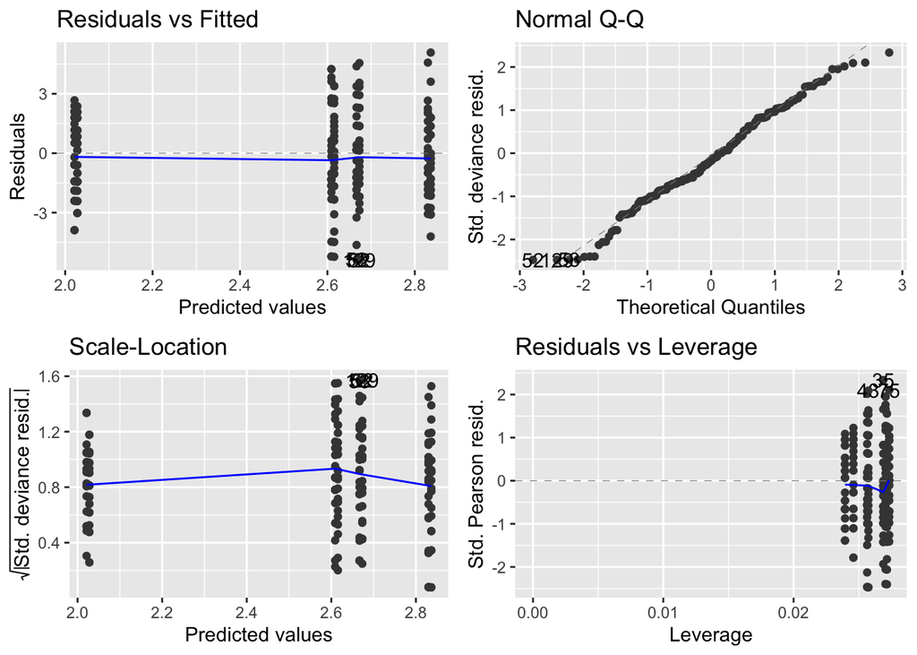

```r
# ===== Generalized Linear Model =====

# Create generalized linear model.
model_4 <- glm(totalfruits ~ herbivory + pollination,
               data = cucumber_damage,
               family = quasipoisson)

# Generate diagnostic plots to check model_4 assumptions.
autoplot(model_4)
```

```r
# Perform ANOVA test on model_4 significance of predictors.
anova(model_4)
```

```
## Analysis of Deviance Table
##
## Model: quasipoisson, link: log
##
## Response: totalfruits
##
## Terms added sequentially (first to last)
##
##
##             Df Deviance Resid. Df Resid. Dev       F    Pr(>F)
## NULL                          191    1187.95
## herbivory    3  188.707       188     999.25 12.9286 1.033e-07 ***
## pollination  1    0.027       187     999.22  0.0056    0.9407
## ---
## Signif. codes:  0 '***' 0.001 '**' 0.01 '*' 0.05 '.' 0.1 ' ' 1
```

```r
# Display summary of model_4.
summary(model_4)
```

```
##
## Call:
## glm(formula = totalfruits ~ herbivory + pollination, family = quasipoisson,
##     data = cucumber_damage)
##
## Coefficients:
##                Estimate Std. Error t value Pr(>|t|)
## (Intercept)    2.027833   0.123841  16.375  < 2e-16 ***
## herbivoryL     0.645427   0.142875   4.517 1.11e-05 ***
## herbivoryM     0.587730   0.146404   4.014 8.62e-05 ***
## herbivoryO     0.808572   0.139682   5.789 2.95e-08 ***
## pollinationNP -0.006527   0.087603  -0.075    0.941
## ---
## Signif. codes:  0 '***' 0.001 '**' 0.01 '*' 0.05 '.' 0.1 ' ' 1
##
## (Dispersion parameter for quasipoisson family taken to be 4.865345)
##
##     Null deviance: 1187.95  on 191  degrees of freedom
## Residual deviance:  999.22  on 187  degrees of freedom
##   (8 observations deleted due to missingness)
## AIC: NA
##
## Number of Fisher Scoring iterations: 5
```